# Project 4 – Red Wine Quality Dataset Exploration by Mark Cassar

# Check for missing data

I want to see if there are any ‘na’, null or missing values in the data.

```
##                    X        fixed.acidity     volatile.acidity
##                    0                    0                    0
##          citric.acid       residual.sugar            chlorides
##                    0                    0                    0
##  free.sulfur.dioxide total.sulfur.dioxide              density
##                    0                    0                    0
##                   pH            sulphates              alcohol
##                    0                    0                    0
##              quality
##                    0
```

```
##                    X        fixed.acidity     volatile.acidity
##                    0                    0                    0
##          citric.acid       residual.sugar            chlorides
##                    0                    0                    0
##  free.sulfur.dioxide total.sulfur.dioxide              density
##                    0                    0                    0
##                   pH            sulphates              alcohol
##                    0                    0                    0
##              quality
##                    0
```

```
##                    X        fixed.acidity     volatile.acidity
##                    0                    0                    0
##          citric.acid       residual.sugar            chlorides
##                    0                    0                    0
##  free.sulfur.dioxide total.sulfur.dioxide              density
##                    0                    0                    0
##                   pH            sulphates              alcohol
##                    0                    0                    0
##              quality
##                    0
```

# Basic info

What is the size of the dataset, what variables are included, what data types are the variables and what are the summary stats?

```
## [1] 1599   13
```

```
##  [1] "X"                    "fixed.acidity"        "volatile.acidity"
##  [4] "citric.acid"          "residual.sugar"       "chlorides"
##  [7] "free.sulfur.dioxide"  "total.sulfur.dioxide" "density"
## [10] "pH"                   "sulphates"            "alcohol"
## [13] "quality"
```

```
## Classes 'tbl_df', 'tbl' and 'data.frame':    1599 obs. of  13 variables:
##  $ X                   : int  1 2 3 4 5 6 7 8 9 10 ...
##  $ fixed.acidity       : num  7.4 7.8 7.8 11.2 7.4 7.4 7.9 7.3 7.8 7.5 ...
##  $ volatile.acidity    : num  0.7 0.88 0.76 0.28 0.7 0.66 0.6 0.65 0.58 0.5 ...
##  $ citric.acid         : num  0 0 0.04 0.56 0 0 0.06 0 0.02 0.36 ...
##  $ residual.sugar      : num  1.9 2.6 2.3 1.9 1.9 1.8 1.6 1.2 2 6.1 ...
##  $ chlorides           : num  0.076 0.098 0.092 0.075 0.076 0.075 0.069 0.065 0.073 0.071 ...
##  $ free.sulfur.dioxide : num  11 25 15 17 11 13 15 15 9 17 ...
##  $ total.sulfur.dioxide: num  34 67 54 60 34 40 59 21 18 102 ...
##  $ density             : num  0.998 0.997 0.997 0.998 0.998 ...
##  $ pH                  : num  3.51 3.2 3.26 3.16 3.51 3.51 3.3 3.39 3.36 3.35 ...
##  $ sulphates           : num  0.56 0.68 0.65 0.58 0.56 0.56 0.46 0.47 0.57 0.8 ...
##  $ alcohol             : num  9.4 9.8 9.8 9.8 9.4 9.4 9.4 10 9.5 10.5 ...
##  $ quality             : int  5 5 5 6 5 5 5 7 7 5 ...
```

```
##        X          fixed.acidity   volatile.acidity  citric.acid
##  Min.   :   1.0   Min.   : 4.60   Min.   :0.1200   Min.   :0.000
##  1st Qu.: 400.5   1st Qu.: 7.10   1st Qu.:0.3900   1st Qu.:0.090
##  Median : 800.0   Median : 7.90   Median :0.5200   Median :0.260
##  Mean   : 800.0   Mean   : 8.32   Mean   :0.5278   Mean   :0.271
##  3rd Qu.:1199.5   3rd Qu.: 9.20   3rd Qu.:0.6400   3rd Qu.:0.420
##  Max.   :1599.0   Max.   :15.90   Max.   :1.5800   Max.   :1.000
##  residual.sugar     chlorides       free.sulfur.dioxide
##  Min.   : 0.900   Min.   :0.01200   Min.   : 1.00
##  1st Qu.: 1.900   1st Qu.:0.07000   1st Qu.: 7.00
##  Median : 2.200   Median :0.07900   Median :14.00
##  Mean   : 2.539   Mean   :0.08747   Mean   :15.87
##  3rd Qu.: 2.600   3rd Qu.:0.09000   3rd Qu.:21.00
##  Max.   :15.500   Max.   :0.61100   Max.   :72.00
##  total.sulfur.dioxide    density             pH          sulphates
##  Min.   :  6.00       Min.   :0.9901   Min.   :2.740   Min.   :0.3300
##  1st Qu.: 22.00       1st Qu.:0.9956   1st Qu.:3.210   1st Qu.:0.5500
##  Median : 38.00       Median :0.9968   Median :3.310   Median :0.6200
##  Mean   : 46.47       Mean   :0.9967   Mean   :3.311   Mean   :0.6581
##  3rd Qu.: 62.00       3rd Qu.:0.9978   3rd Qu.:3.400   3rd Qu.:0.7300
##  Max.   :289.00       Max.   :1.0037   Max.   :4.010   Max.   :2.0000
##     alcohol         quality
##  Min.   : 8.40   Min.   :3.000
##  1st Qu.: 9.50   1st Qu.:5.000
##  Median :10.20   Median :6.000
##  Mean   :10.42   Mean   :5.636
##  3rd Qu.:11.10   3rd Qu.:6.000
##  Max.   :14.90   Max.   :8.000
```

# Univariate Plots Section

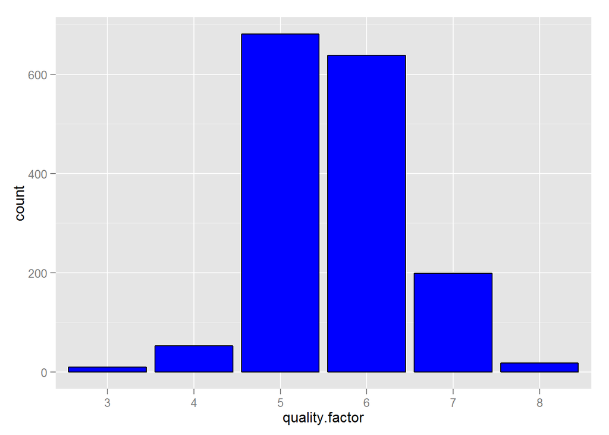

```
## [1] 0.8248906
```

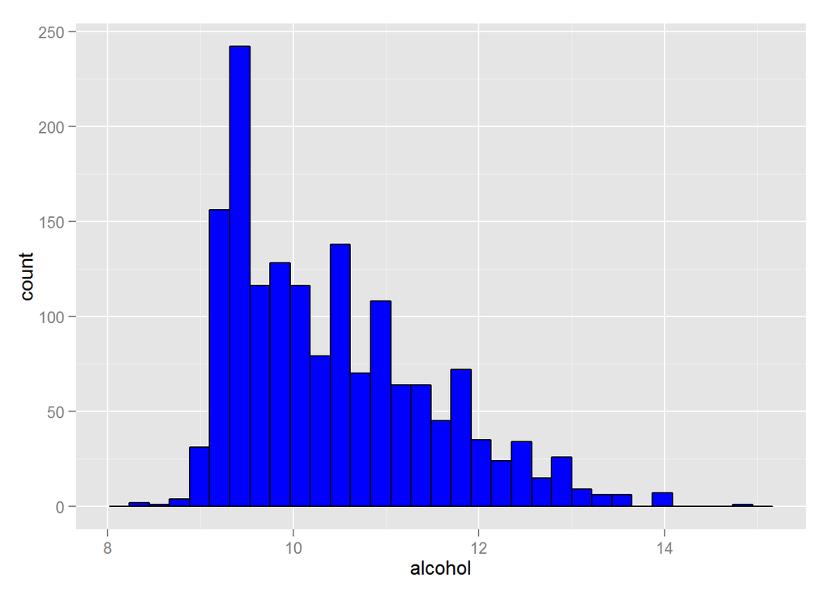

```
##    Min. 1st Qu.  Median    Mean 3rd Qu.    Max.
##    8.40    9.50   10.20   10.42   11.10   14.90
```

```
## [1] 0.7448405
```

Most of the wines, just over 82%, have a quality rating of 5 or 6 and almost 75% have an alcohol % between 9 and 11.

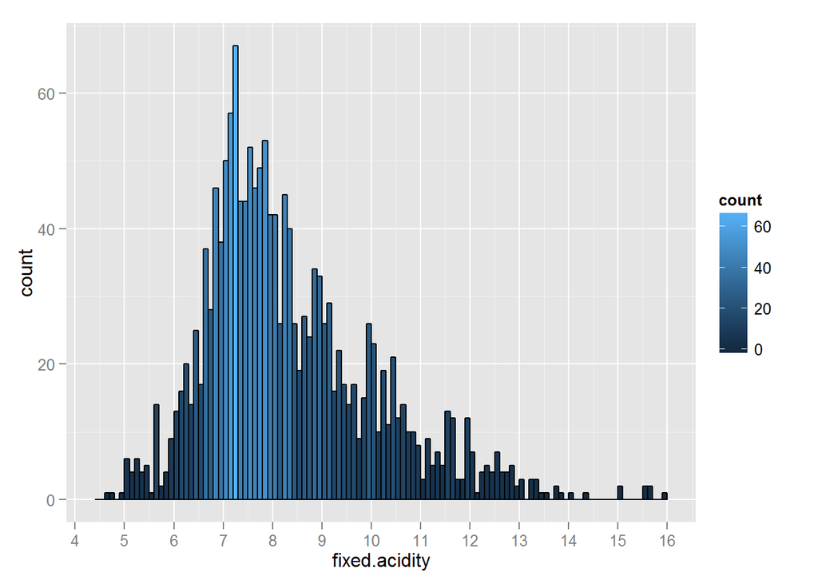

```
## [1] 8
```

```
##    Min. 1st Qu.  Median    Mean 3rd Qu.    Max.
##    4.60    7.10    7.90    8.32    9.20   15.90
```

Fixed acidity levels fall between 7 and 9 for 50% of the wines with a median of 7.9. It is right-skewed, with a mean of 8.3 and about 8 wines having a value above 14. It may be multimodal with a main peak just over 7 and minor peaks at 9, 10, and 11.5.

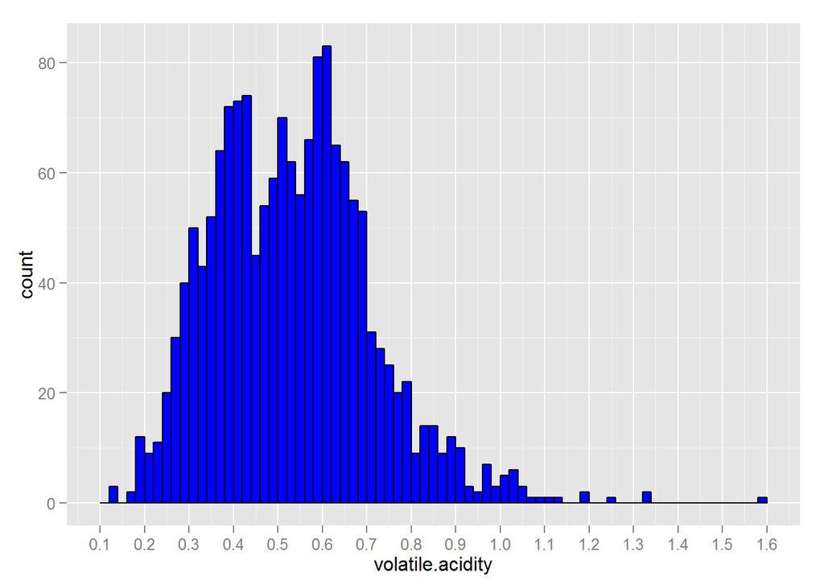

```
## [1] 3
```

```
##    Min. 1st Qu.  Median    Mean 3rd Qu.    Max.
##  0.1200  0.3900  0.5200  0.5278  0.6400  1.5800
```

Volatile acidity levels are mainly in the range of 0.4 to 0.6 and show a bimodal distribuation with one peak at 0.4 and the other at 0.6. There is one outlier with a value around 1.6.

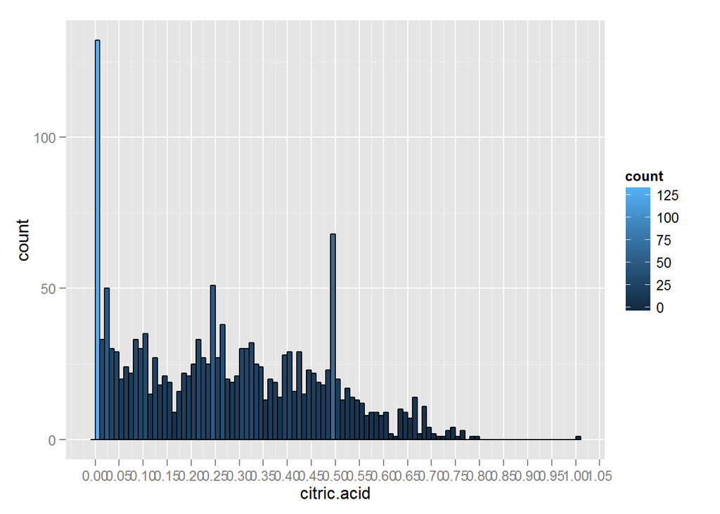

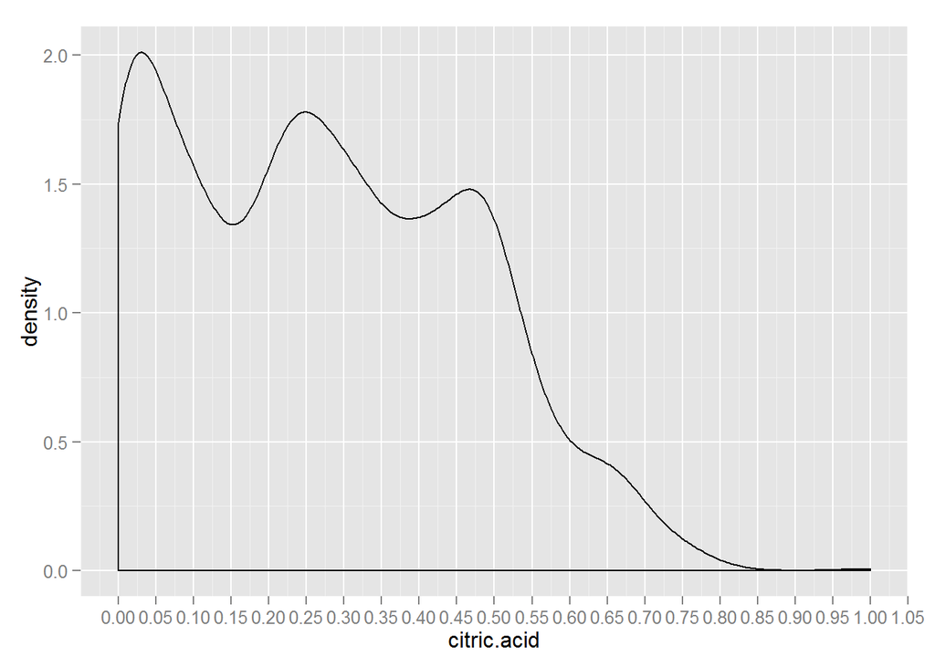

```
##    Min. 1st Qu.  Median    Mean 3rd Qu.    Max.
##   0.000   0.090   0.260   0.271   0.420   1.000
```

The values for citric acid are less normally distributed than those for volatile acidity or fixed acidity.It also shows 3 spikes: the largest just above 0 and the others at 0.25, and just under 0.5.

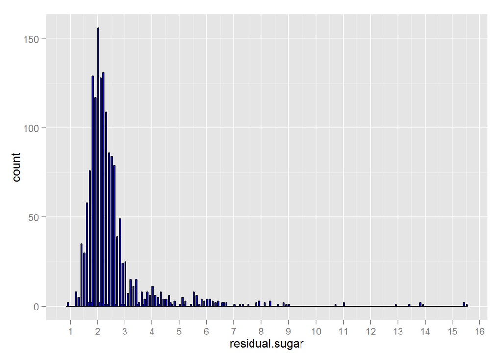

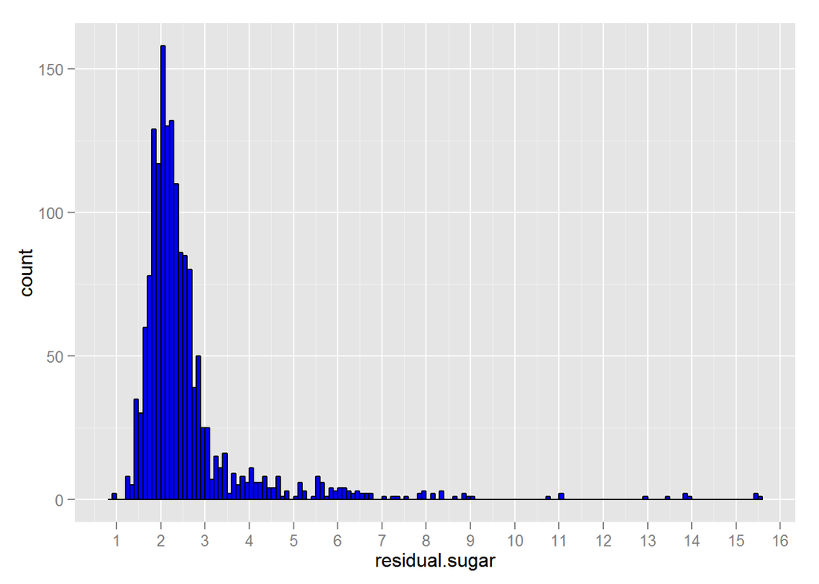

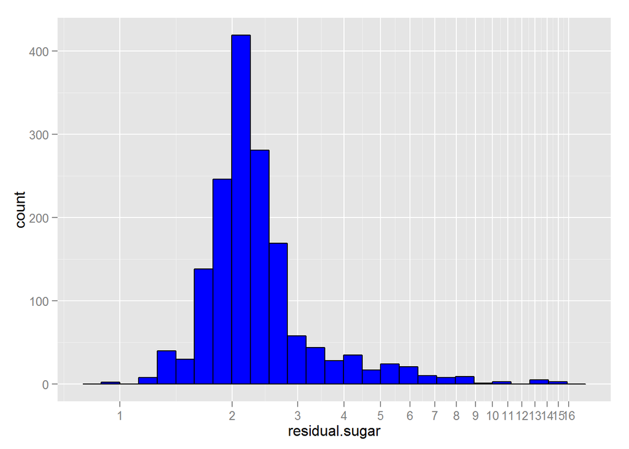

```
##
##  0.9  1.2  1.3  1.4  1.5  1.6 1.65  1.7 1.75  1.8  1.9    2 2.05  2.1 2.15
##    2    8    5   35   30   58    2   76    2  129  117  156    2  128    2
##  2.2 2.25  2.3 2.35  2.4  2.5 2.55  2.6 2.65  2.7  2.8 2.85  2.9 2.95    3
##  131    1  109    1   86   84    1   79    1   39   49    1   24    1   25
##  3.1  3.2  3.3  3.4 3.45  3.5  3.6 3.65  3.7 3.75  3.8  3.9    4  4.1  4.2
##    7   15   11   15    1    2    8    1    4    1    8    6   11    6    5
## 4.25  4.3  4.4  4.5  4.6 4.65  4.7  4.8    5  5.1 5.15  5.2  5.4  5.5  5.6
##    1    8    4    4    6    2    1    3    1    5    1    3    1    8    6
##  5.7  5.8  5.9    6  6.1  6.2  6.3  6.4 6.55  6.6  6.7    7  7.2  7.3  7.5
##    1    4    3    4    4    3    2    3    2    2    2    1    1    1    1
##  7.8  7.9  8.1  8.3  8.6  8.8  8.9    9 10.7   11 12.9 13.4 13.8 13.9 15.4
##    2    3    2    3    1    2    1    1    1    2    1    1    2    1    2
## 15.5
##    1
```

Most values for residual sugar fall between 1.5 and 3 with a long tail out to a value of 15.5. While the values seem to be measured to an accuracy of 5/100 the majority of the values are at the tenth’s accuracy.

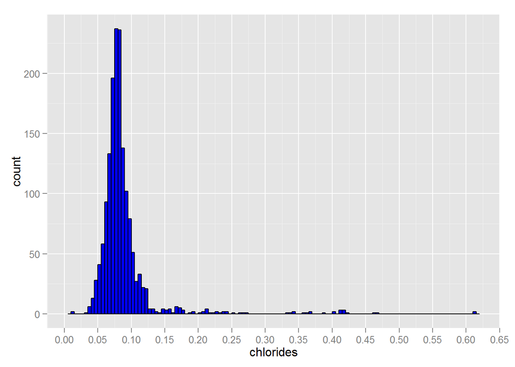

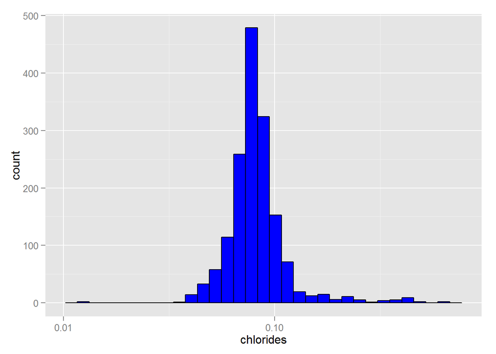

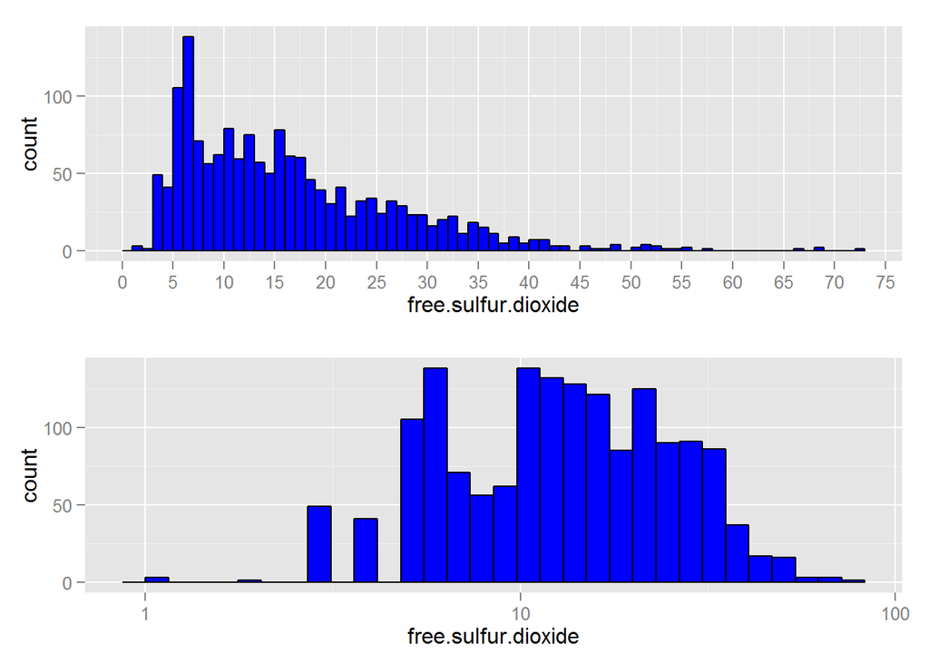

Log transformed free sulfur dioxide distribution appears to be bimodal.

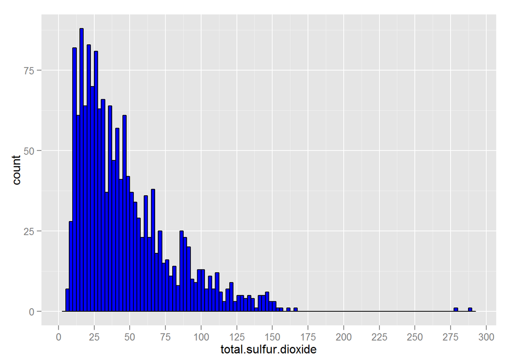

Take a look at the outlier values above 275. Do these wines have outlier values for some of the other variables?

```
##        X        fixed.acidity volatile.acidity  citric.acid
##  Min.   :1080   Min.   :7.9   Min.   :0.3      Min.   :0.68
##  1st Qu.:1080   1st Qu.:7.9   1st Qu.:0.3      1st Qu.:0.68
##  Median :1081   Median :7.9   Median :0.3      Median :0.68
##  Mean   :1081   Mean   :7.9   Mean   :0.3      Mean   :0.68
##  3rd Qu.:1082   3rd Qu.:7.9   3rd Qu.:0.3      3rd Qu.:0.68
##  Max.   :1082   Max.   :7.9   Max.   :0.3      Max.   :0.68
##  residual.sugar   chlorides    free.sulfur.dioxide total.sulfur.dioxide
##  Min.   :8.3    Min.   :0.05   Min.   :37.5        Min.   :278.0
##  1st Qu.:8.3    1st Qu.:0.05   1st Qu.:37.5        1st Qu.:280.8
##  Median :8.3    Median :0.05   Median :37.5        Median :283.5
##  Mean   :8.3    Mean   :0.05   Mean   :37.5        Mean   :283.5
##  3rd Qu.:8.3    3rd Qu.:0.05   3rd Qu.:37.5        3rd Qu.:286.2
##  Max.   :8.3    Max.   :0.05   Max.   :37.5        Max.   :289.0
##     density             pH         sulphates       alcohol        quality
##  Min.   :0.9932   Min.   :3.01   Min.   :0.51   Min.   :12.3   Min.   :7
##  1st Qu.:0.9932   1st Qu.:3.01   1st Qu.:0.51   1st Qu.:12.3   1st Qu.:7
##  Median :0.9932   Median :3.01   Median :0.51   Median :12.3   Median :7
##  Mean   :0.9932   Mean   :3.01   Mean   :0.51   Mean   :12.3   Mean   :7
##  3rd Qu.:0.9932   3rd Qu.:3.01   3rd Qu.:0.51   3rd Qu.:12.3   3rd Qu.:7
##  Max.   :0.9932   Max.   :3.01   Max.   :0.51   Max.   :12.3   Max.   :7
##  quality.factor
##  3:0
##  4:0
##  5:0
##  6:0
##  7:2
##  8:0
```

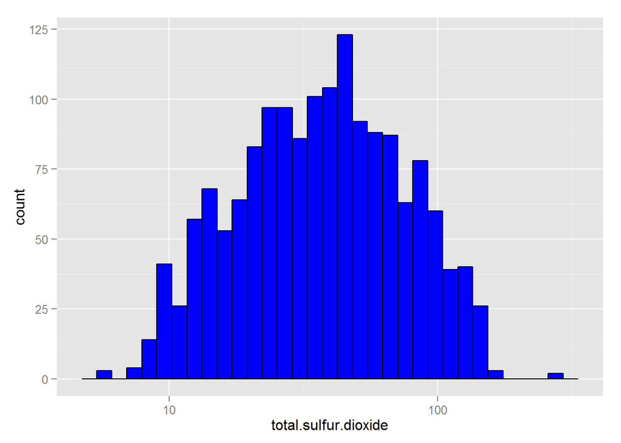

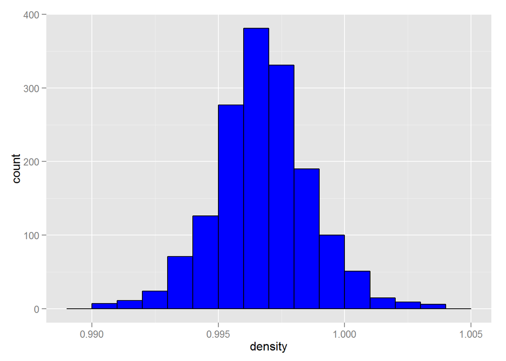

Density values are quite normally distributed with most wines slightly less dense than water.

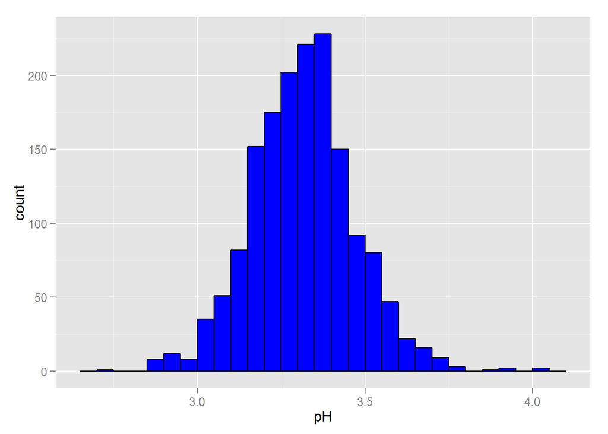

```
##    Min. 1st Qu.  Median    Mean 3rd Qu.    Max.
##   2.740   3.210   3.310   3.311   3.400   4.010
```

pH shows a symmetric distribution with a mean and median value of 3.31.

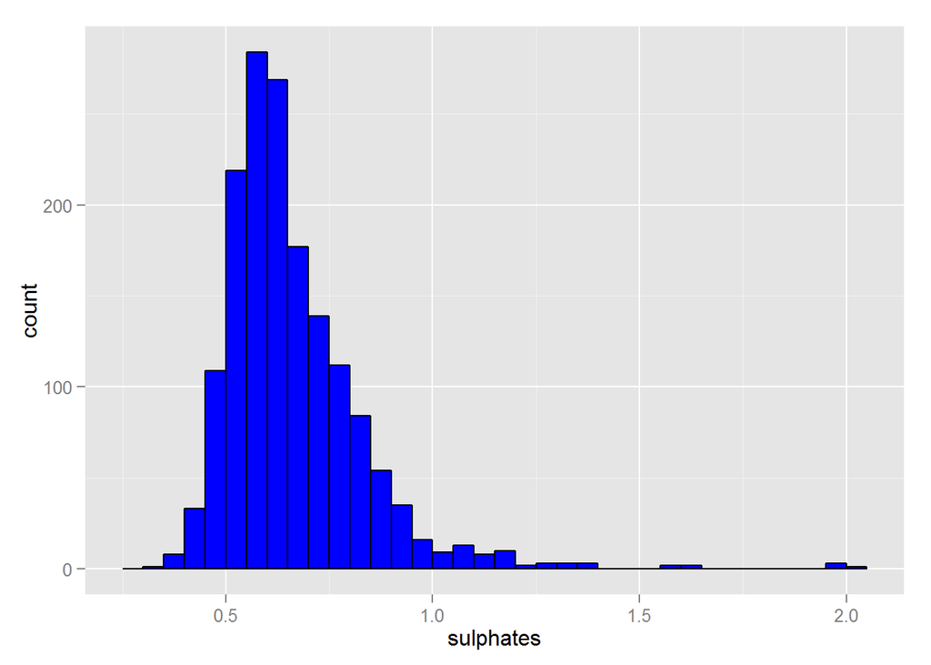

Now let’s look at some ratios. In particular, those for fixed to volatile acidity and for free to total sulfur dioxide. First check for division by zero.

```
##
##  0.12  0.16  0.18  0.19   0.2  0.21  0.22  0.23  0.24  0.25  0.26  0.27
##     3     2    10     2     3     6     6     5    13     7    16    14
##  0.28  0.29 0.295   0.3 0.305  0.31 0.315  0.32  0.33  0.34  0.35  0.36
##    23    16     1    16     2    30     2    23    20    30    22    38
## 0.365  0.37  0.38  0.39 0.395   0.4  0.41 0.415  0.42  0.43  0.44  0.45
##     2    24    35    35     2    37    33     3    31    43    23    22
##  0.46  0.47 0.475  0.48  0.49   0.5  0.51  0.52  0.53  0.54 0.545  0.55
##    31    21     2    24    35    46    24    33    29    31     5    20
##  0.56 0.565  0.57 0.575  0.58 0.585  0.59 0.595   0.6 0.605  0.61 0.615
##    34     1    28     3    38     3    39     1    47     3    27     6
##  0.62 0.625  0.63 0.635  0.64 0.645  0.65 0.655  0.66 0.665  0.67 0.675
##    24     3    29     9    27    12    16     7    26     3    23     3
##  0.68 0.685  0.69 0.695   0.7 0.705  0.71 0.715  0.72 0.725  0.73 0.735
##    12    11    23     7    10     6     3    12     5     9     6     8
##  0.74 0.745  0.75 0.755  0.76 0.765  0.77 0.775  0.78 0.785  0.79 0.795
##    11     5     6     3     5     5     6     4    10     8     2     2
##   0.8 0.805  0.81 0.815  0.82 0.825  0.83 0.835  0.84 0.845  0.85 0.855
##     3     1     2     3     5     1     4     4     8     1     2     3
##  0.86 0.865  0.87 0.875  0.88 0.885  0.89 0.895   0.9  0.91 0.915  0.92
##     2     1     4     2     5     5     1     1     3     3     4     1
## 0.935  0.95 0.955  0.96 0.965 0.975  0.98     1 1.005  1.01  1.02 1.025
##     2     1     1     3     3     1     3     3     1     1     4     1
## 1.035  1.04  1.07  1.09 1.115  1.13  1.18 1.185  1.24  1.33  1.58
##     1     3     1     1     1     1     1     1     1     2     1
```

```
##
##    6    7    8    9   10   11   12   13   14   15   16   17   18   19   20
##    3    4   14   14   27   26   29   28   33   35   26   27   35   29   33
##   21   22   23   24   25   26   27   28   29   30   31   32   33   34   35
##   25   25   34   36   27   24   30   43   20   14   32   20   17   20   26
##   36   37   38   39   40   41   42   43   44   45   46   47   48   49   50
##   12   26   31   16   17   14   26   18   23   20   17   24   21   21   11
##   51   52   53   54   55   56   57   58   59   60   61   62   63   64   65
##   11   15   14   20   13   10    6   14    9   18    9    9   13   10   17
##   66   67   68   69   70   71   72   73   74   75   76   77 77.5   78   79
##    9   12   10    8    8    7   10    7    8    5    3    8    2    4    5
##   80   81   82   83   84   85   86   87   88   89   90   91   92   93   94
##    4    6    4    2    6    9   10    6   14    9    5    7    8    2    8
##   95   96   98   99  100  101  102  103  104  105  106  108  109  110  111
##    4    5    7    6    3    4    6    2    5    5    6    3    4    6    3
##  112  113  114  115  116  119  120  121  122  124  125  126  127  128  129
##    3    4    2    2    1    7    2    4    3    3    2    1    2    2    3
##  130  131  133  134  135  136  139  140  141  142  143  144  145  147  148
##    1    3    3    2    2    2    1    1    3    1    2    3    3    3    2
##  149  151  152  153  155  160  165  278  289
##    1    2    1    1    1    1    1    1    1
```

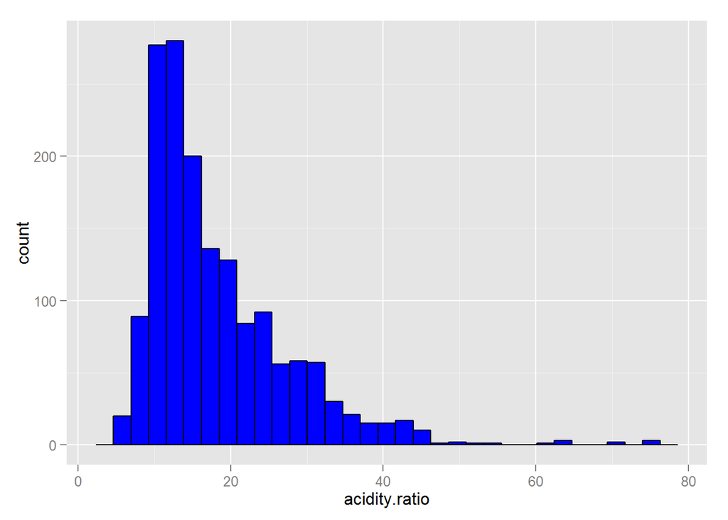

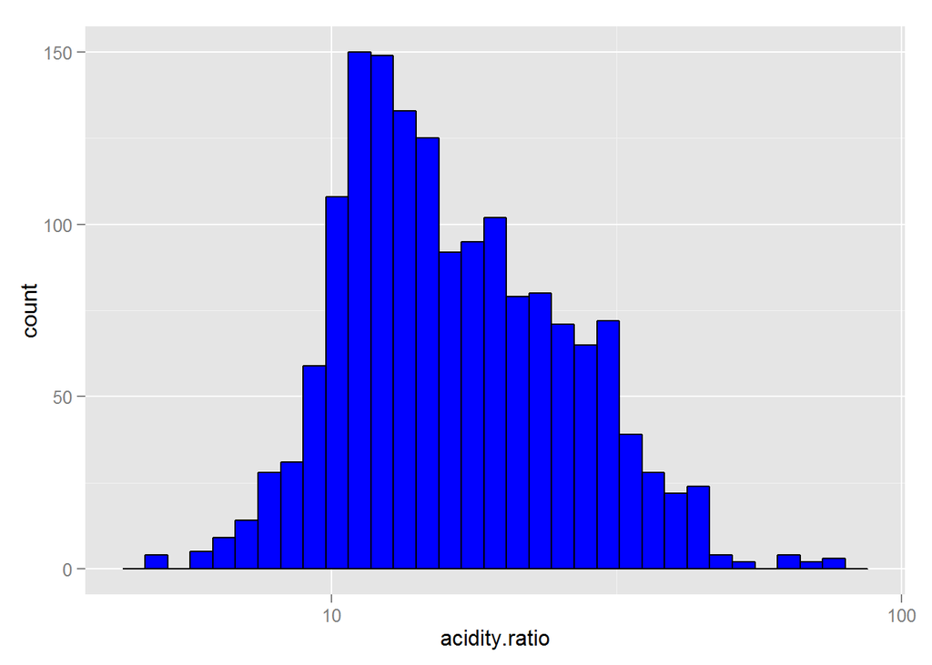

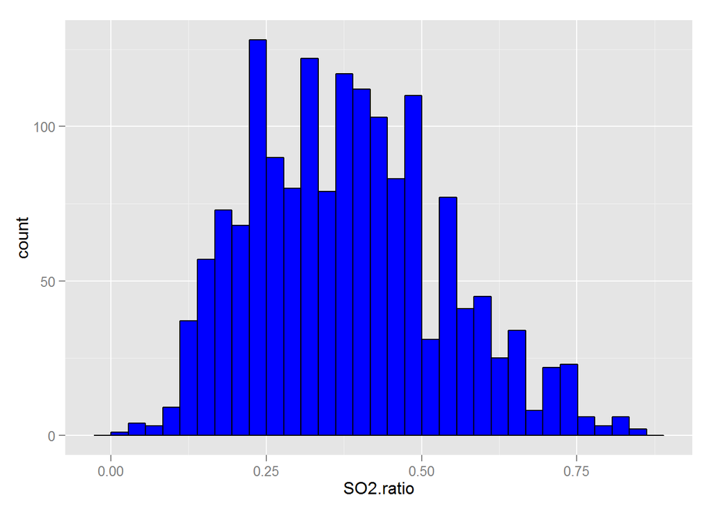

Both ratios appear to be more normally distributed than the individual variables were so these may come in handy if I create a linear model.

## Outliers

I’ll finish off this section by getting an overview of the outliers in the dataset. I consider a value for a given variable to be an outlier if it is less than 1.5(IQR) below the first quartile or greater than 1.5(IQR) above the third quartile. To get a bit better of a picture of the outliers, I will create a new data frame where the values for each variable, and for each wine, will be replaced by a 1 if it represents an outlier value, or a 0 if it does not.

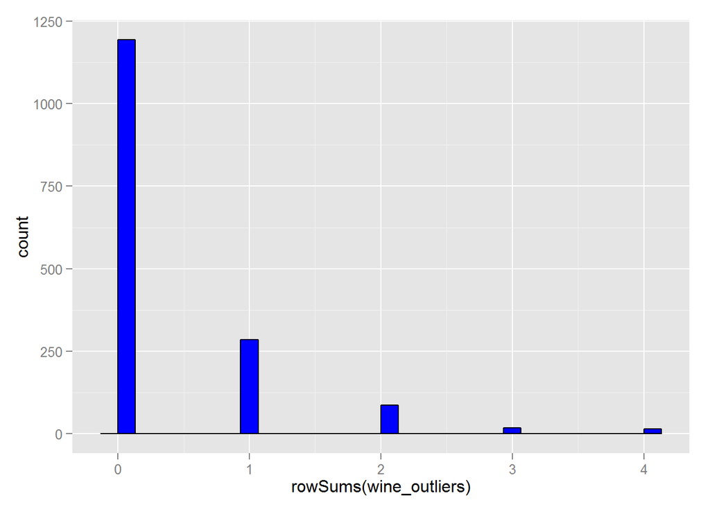

```
##
##    0    1    2    3    4
## 1194  285   87   18   15
```

In the plot above we are looking at the number of wines that have outlier values for a certain number of variables. In this dataset the most outlier values that a single wine has is 4. And there are only 15 (out of 1599) of those, as noted in the table. So, the majority of wines (1479/1599 = 0.925) have 0 or 1 characteristic that can be considered an outlier.

For comparison, let’s now look at how many wines in each variable have outlier values.

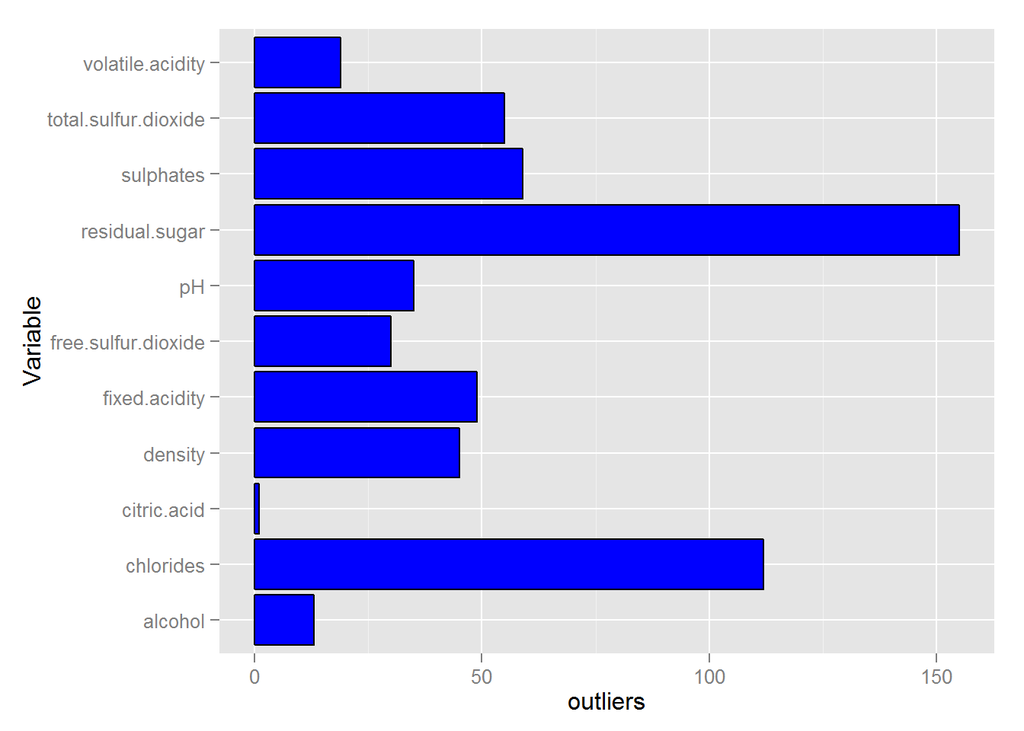

Here we see what the histograms have already shown, that residual sugar and chlorides have the most wines with outlier values. Most of the variables have about 3% or fewer of the wines having outlier values.

# Univariate Analysis

### What is the structure of your dataset?

There are 1599 different wines in the dataset with 12 features. The features are:

- fixed acidity
- volatile acidity
- citric acid
- residual sugar
- chlorides
- free sulfur dioxide
- total sulfur dioxide
- density
- pH
- sulphates
- alcohol
- quality

The first 11 are numerical with the last one originally in integer format, though I converted it into a factor.

About 82% of the wines have a quality rating of 5 or 6 and about 75% have between 9-11% alcohol.The former percentage may make it difficult to create a reliable model to predict quality in the range of 1-10 as there are many fewer observations outside of 5 and 6.

### What is/are the main feature(s) of interest in your dataset?

The feature of interest is quality.

### What other features in the dataset do you think will help support your investigation into your feature(s) of interest?

I think the acidity, sugar, and alcohol features will be important.

### Did you create any new variables from existing variables in the dataset?

I create new variables based on the ratios of the other variables:

- acidity.ratio = fixed.acidity / volatile.acidity
- SO2.ratio = free.sulfur.dioxide / total.sulfur.dioxide

### Of the features you investigated, were there any unusual distributions? Did you perform any operations on the data to tidy, adjust, or change the form of the data? If so, why did you do this?

I log transformed the right-skewed data for residual sugar, chlorides, sulfur dioxide, and acidity ratio.

# Bivariate Plots Section

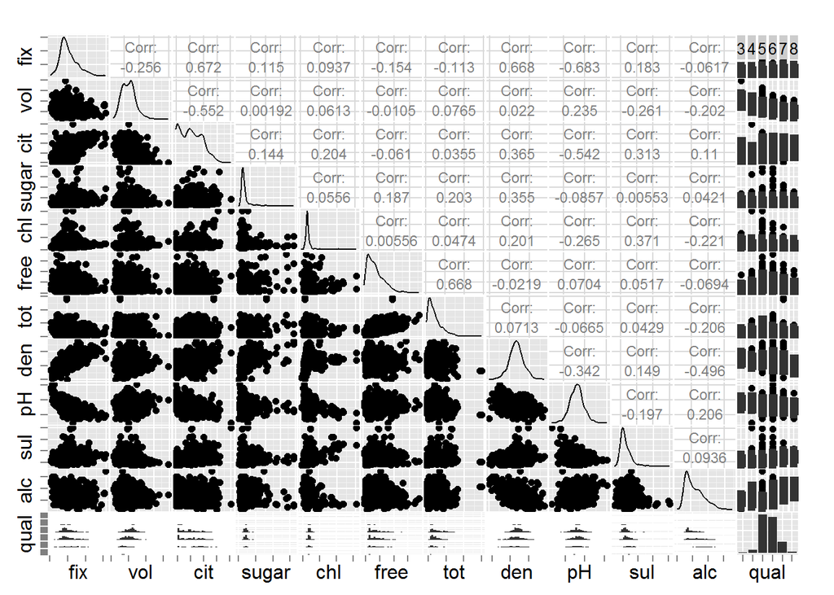

This shows that the most correlated variables are:

| Variable_1 | Variable_2 | Correlation |
| --- | --- | --- |
| fixed.acidity | citric.acid | 0.672 |
| fixed.acidity | density | 0.668 |
| fixed.acidity | pH | -0.683 |
| volatile.acidity | citric.acid | -0.552 |
| citric.acid | pH | -0.542 |
| free.SO2 | total.SO2 | 0.668 |

Before looking at these more closely, and especially since there are only 11 variables, I want to see how eac one is correlated (or not) with quality.

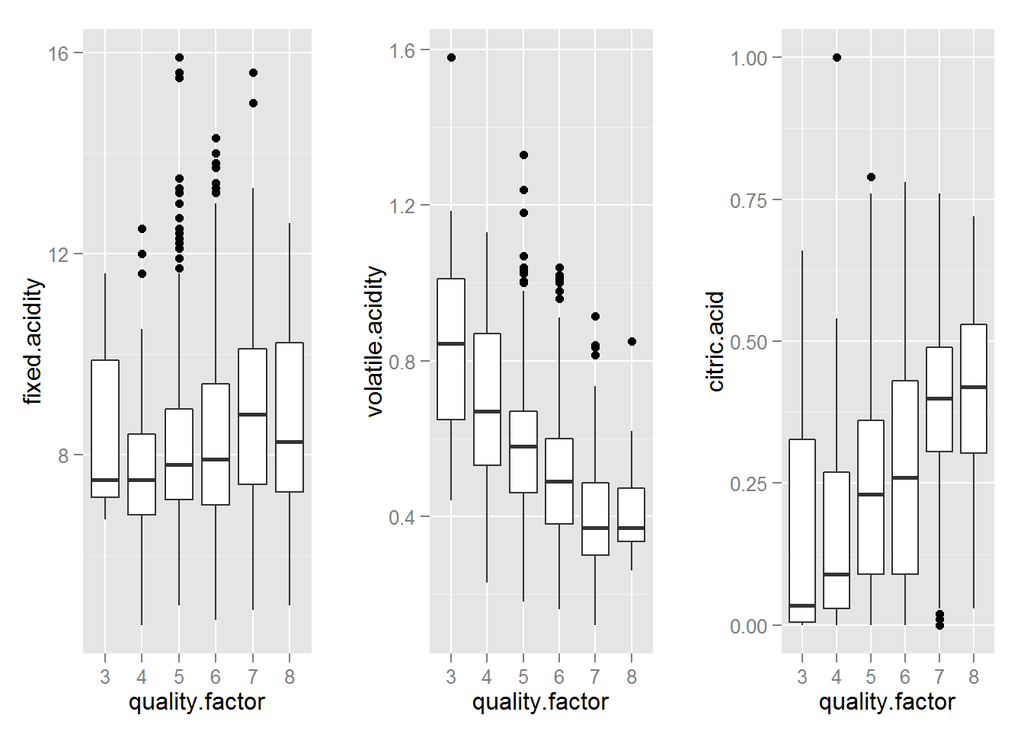

There seems to be some fairly clear linear relationships between quality and acidity, particularly with volatile.acidity and citric.acid with the former being an inverse relation. Correlation between volatile.acidity and quality is

```
## [1] -0.3905578
```

and between citric.acid and quality it is

```
## [1] 0.2263725
```

The stronger connection to volatile.acidity is not obvious from the chart so let me plot them again with the same y axis and with volatile.acidity inverted (so the slope are both positive).

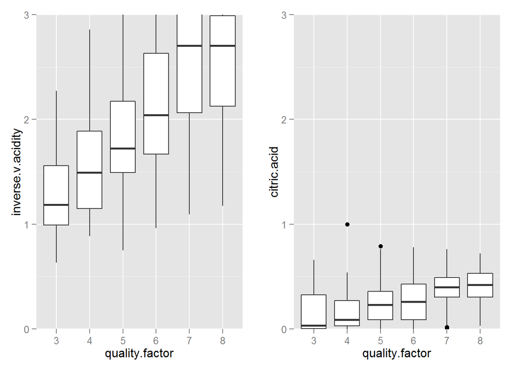

That much more clearly shows the stronger relationship between quality and volatile.acidity.

What about quality and the ratio of these two?

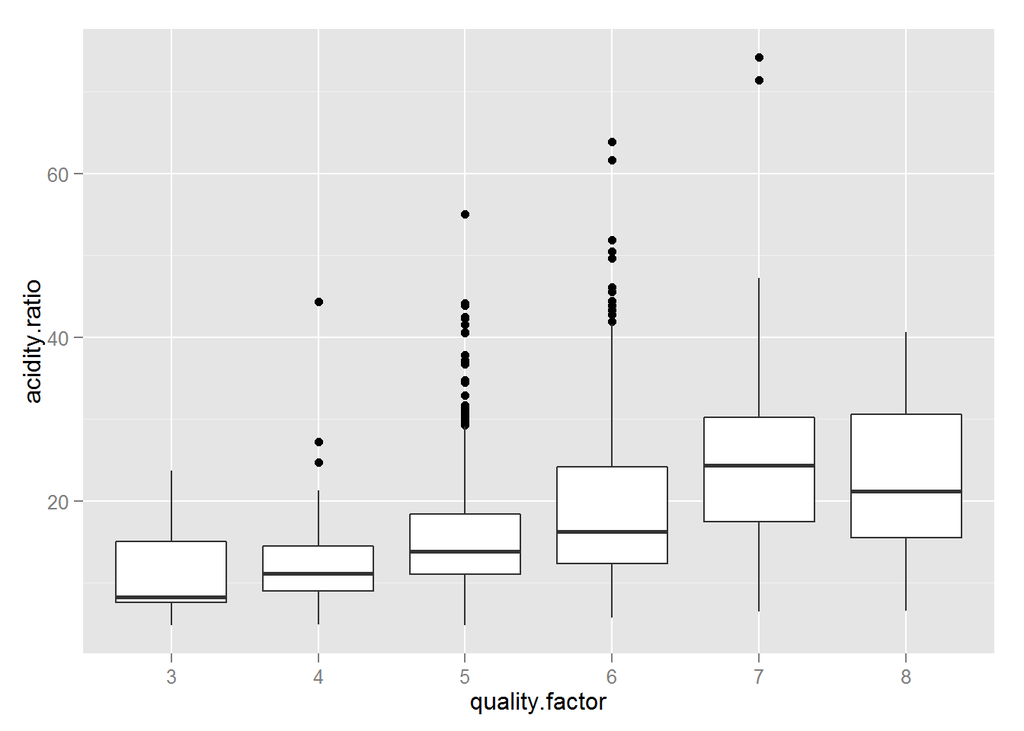

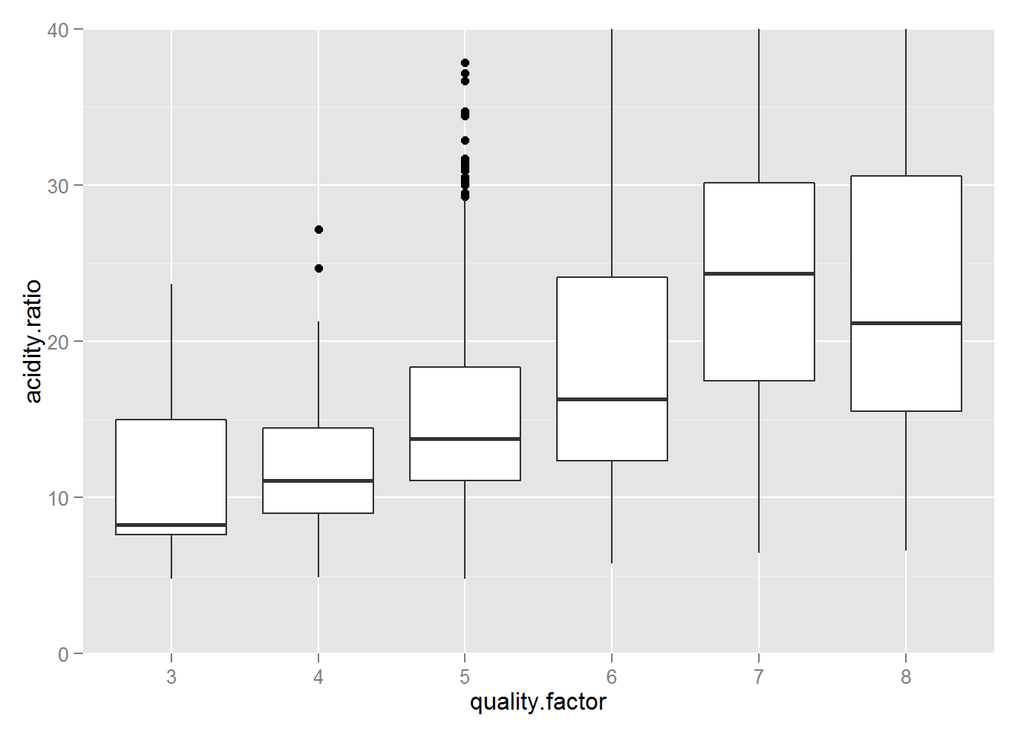

Seems fairly linear, except for the drop at a quality rating of 8. Also looks like the variability increases with quality. The correlation is

```
## [1] 0.3434631
```

which is close to what I saw for volatile.acidity, just a bit lower. Seems like it’s best to stick with volatile.acidity (or its inverse) for predictive power.

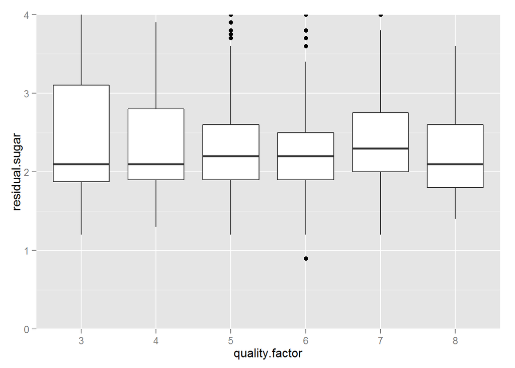

Not much variation of residual.sugar with quality, although quite a few outliers for quality levels 5, 6, and 7. Correlation coefficient is

```
## [1] 0.01373164
```

so that confirms what I am seeing.

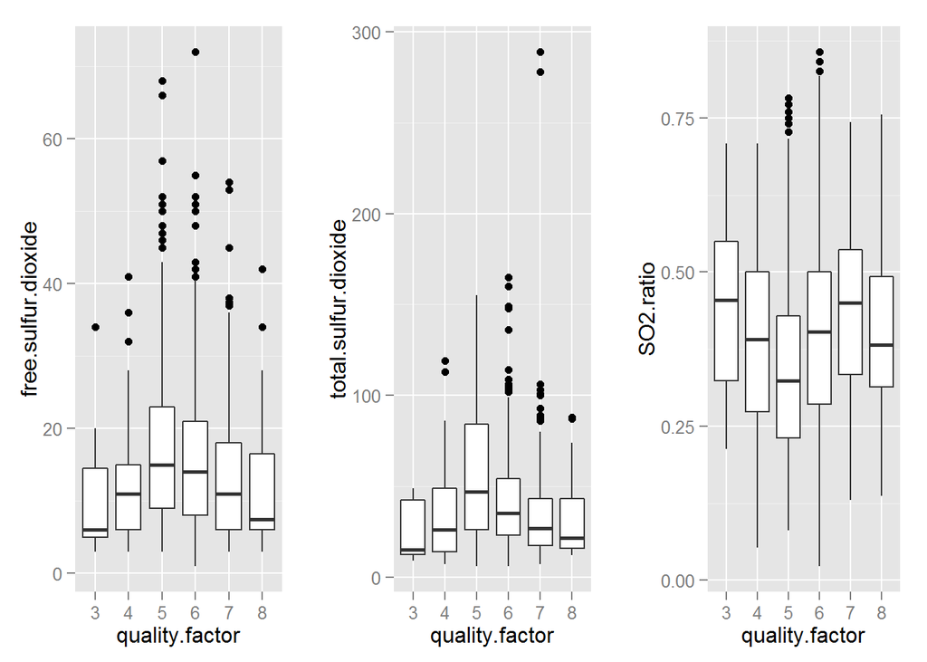

The first two sulfur dioxide relationships look like inverse quadratic relations while the ratio is perhaps cubic. Try square root on first two and cube root on the last.

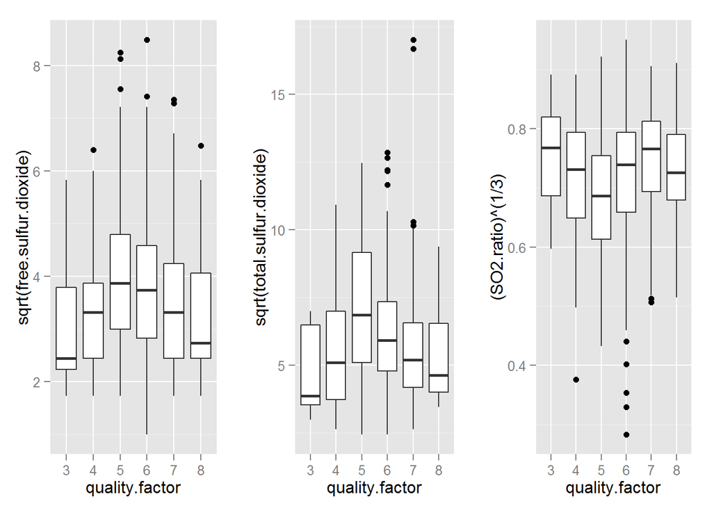

How does the correlation change after applying the transformations:

free.sulfur.dioxide original correlation, new, and percentage change is

```
## [1] -0.05065606
```